# London House Price Prediction

I’ve always been curious about London’s wild property market—crazy price swings in just a few streets! So in this notebook, I cleaned up the raw listings, cooked up a few clever features, and tried out a straight‐ahead regression before moving on to Ridge. Along the way, I’ll show you how each tweak helped the model behave more like a buyer’s intuition.

## Data Acquisition

- **Source**: Kaggle London House Price Data by Jake Wright
- **Link**: [Kaggle Dataset](https://www.kaggle.com/datasets/jakewright/london-house-price-data)
- **License**: Other (specified in description)
- **Description**: Contains 200,000+ London property sales (1995–Oct 2024) with features like postcode, property type, bedrooms, and sale price estimates.

```python
import numpy as np
import pandas as pd
import matplotlib.pyplot as plt
import seaborn as sns
from sklearn.metrics import r2_score as r2, mean_absolute_error as mae, mean_squared_error as mse
```

```python
london_house = pd.read_csv("kaggle_london_house_price_data.csv")
london_house.head()
```

|  | fullAddress | postcode | country | outcode | latitude | longitude | bathrooms | bedrooms | floorAreaSqM | livingRooms | ... | saleEstimate_upperPrice | saleEstimate_confidenceLevel | saleEstimate_ingestedAt | saleEstimate_valueChange.numericChange | saleEstimate_valueChange.percentageChange | saleEstimate_valueChange.saleDate | history_date | history_price | history_percentageChange | history_numericChange |
| --- | --- | --- | --- | --- | --- | --- | --- | --- | --- | --- | --- | --- | --- | --- | --- | --- | --- | --- | --- | --- | --- |
| 0 | Flat 9, 35 Furnival Street, London, EC4A 1JQ | EC4A 1JQ | England | EC4A | 51.517282 | -0.110314 | 1.0 | 1.0 | 45.0 | 1.0 | ... | 630000.0 | HIGH | 2024-10-07T13:26:59.894Z | 244000.0 | 68.539326 | 2010-03-30 | 1995-01-02 | 830000 | NaN | NaN |
| 1 | Flat 6, 35 Furnival Street, London, EC4A 1JQ | EC4A 1JQ | England | EC4A | 51.517282 | -0.110314 | NaN | NaN | NaN | NaN | ... | 660000.0 | MEDIUM | 2024-10-07T13:26:59.894Z | 425000.0 | 242.857143 | 2000-05-26 | 1995-01-02 | 830000 | NaN | NaN |
| 2 | Flat 35, Octavia House, Medway Street, London,... | SW1P 2TA | England | SW1P | 51.495505 | -0.132379 | 2.0 | 2.0 | 71.0 | 1.0 | ... | 834000.0 | MEDIUM | 2025-01-10T11:04:57.114Z | 49000.0 | 6.901408 | 2019-09-04 | 1995-01-03 | 249950 | NaN | NaN |
| 3 | 24 Chester Court, Lomond Grove, London, SE5 7HS | SE5 7HS | England | SE5 | 51.478185 | -0.092201 | 1.0 | 1.0 | 64.0 | 1.0 | ... | 407000.0 | HIGH | 2024-10-07T13:26:59.894Z | 28000.0 | 7.777778 | 2024-01-25 | 1995-01-03 | 32000 | NaN | NaN |
| 4 | 18 Alexandra Gardens, London, N10 3RL | N10 3RL | England | N10 | 51.588774 | -0.139599 | 1.0 | 4.0 | 137.0 | 2.0 | ... | 1324000.0 | HIGH | 2024-10-07T13:26:59.894Z | 81000.0 | 6.864407 | 2022-12-14 | 1995-01-03 | 133000 | NaN | NaN |

5 rows × 28 columns

```python
london_house.info()
```

```
<class 'pandas.core.frame.DataFrame'>
RangeIndex: 418201 entries, 0 to 418200
Data columns (total 28 columns):
 #   Column                                     Non-Null Count   Dtype
---  ------                                     --------------   -----
 0   fullAddress                                418201 non-null  object
 1   postcode                                   418201 non-null  object
 2   country                                    418201 non-null  object
 3   outcode                                    418201 non-null  object
 4   latitude                                   418201 non-null  float64
 5   longitude                                  418201 non-null  float64
 6   bathrooms                                  340270 non-null  float64
 7   bedrooms                                   377665 non-null  float64
 8   floorAreaSqM                               392991 non-null  float64
 9   livingRooms                                357701 non-null  float64
```

[output cut: 20 more lines]

## Data Filtering

Filter the dataset for transactions from 2023–2024 to focus on recent market trends, ensuring relevance for London's real estate market.

```python
# Extract sale_year from saleEstimate_valueChange.saleDate

london_house["sale_year"] = pd.to_datetime(london_house["saleEstimate_valueChange.saleDate"]
                                           ,errors = 'coerce').dt.year
```

```python
# Filter for 2023–2024

london_house = london_house[london_house['sale_year'].isin([2023, 2024])]
```

```python
# Display

print("Filtered Dataset Shape:", london_house.shape)

print("\nFirst 5 rows of filtered data:")
print(london_house.head())
```

```
Filtered Dataset Shape: (197713, 29)

First 5 rows of filtered data:
                                        fullAddress postcode  country outcode  \
3   24 Chester Court, Lomond Grove, London, SE5 7HS  SE5 7HS  England     SE5
10                36 Leadale Avenue, London, E4 8AY   E4 8AY  England      E4
11                36 Leadale Avenue, London, E4 8AY   E4 8AY  England      E4
12                 89 St Marks Road, London, W7 2PN   W7 2PN  England      W7
14      Flat C, 44 Bramham Gardens, London, SW5 0HQ  SW5 0HQ  England     SW5

     latitude  longitude  bathrooms  bedrooms  floorAreaSqM  livingRooms  ...  \
3   51.478185  -0.092201        1.0       1.0          64.0          1.0  ...
10  51.624030  -0.020209        2.0       4.0         142.0          2.0  ...
11  51.624030  -0.020209        2.0       4.0         142.0          2.0  ...
12  51.504157  -0.341305        NaN       4.0         123.0          NaN  ...
14  51.491719  -0.189176        2.0       2.0          96.0          2.0  ...

   saleEstimate_confidenceLevel   saleEstimate_ingestedAt  \
3                          HIGH  2024-10-07T13:26:59.894Z
10                         HIGH  2025-01-10T11:04:57.114Z
11                         HIGH  2024-10-07T13:26:59.894Z
12                       MEDIUM  2024-10-07T13:26:59.894Z
14                         HIGH  2024-10-07T13:26:59.894Z

   saleEstimate_valueChange.numericChange  \
3                                 28000.0
10                                20000.0
11                                 9000.0
12                                80000.0
14                              -139000.0

    saleEstimate_valueChange.percentageChange  \
3                                    7.777778
10                                   3.448276
11                                   1.551724
12                                  11.428571
14                                  -7.533875

    saleEstimate_valueChange.saleDate  history_date  history_price  \
3                          2024-01-25    1995-01-03          32000
10                         2024-04-19    1995-01-03          82500
11                         2024-04-19    1995-01-03          82500
12                         2024-03-28    1995-01-03          45000
14                         2023-09-22    1995-01-04         313000

    history_percentageChange  history_numericChange sale_year
3                        NaN                    NaN    2024.0
10                       NaN                    NaN    2024.0
11                       NaN                    NaN    2024.0
12                       NaN                    NaN    2024.0
14                       NaN                    NaN    2023.0

[5 rows x 29 columns]
```

## Why,How We Filtered the Data and Why I Narrowed Down to 2023–24 Sales

When I opened up those 418 000+ rows covering 1995 through 2024, I realized most of that history didn’t reflect today’s London market. Prices have more than doubled since the 2010s, and what counts as “high-end” now is completely different. Instead of wrestling with decades of outdated data, I decided to work with the last two years only.

This way, my model only “sees” prices from today’s market—no ancient history dragging it down.

```python
# Missing values
print("\nMissing Values in Filtered Data:")
```

```
Missing Values in Filtered Data:
```

```python
missing = pd.DataFrame({

    'count': london_house.isnull().sum(),
    'percentage':(london_house.isnull().sum() / len(london_house) * 100).round(2)

})

print(missing)
```

```
                                           count  percentage
fullAddress                                    0        0.00
postcode                                       0        0.00
country                                        0        0.00
outcode                                        0        0.00
latitude                                       0        0.00
longitude                                      0        0.00
bathrooms                                  30489       15.42
bedrooms                                   15356        7.77
floorAreaSqM                               12755        6.45
livingRooms                                23408       11.84
tenure                                      5897        2.98
propertyType                                 709        0.36
currentEnergyRating                        26274       13.29
rentEstimate_lowerPrice                      680        0.34
rentEstimate_currentPrice                    680        0.34
rentEstimate_upperPrice                      680        0.34
saleEstimate_lowerPrice                        0        0.00
saleEstimate_currentPrice                      0        0.00
saleEstimate_upperPrice                        0        0.00
saleEstimate_confidenceLevel                   0        0.00
saleEstimate_ingestedAt                        0        0.00
saleEstimate_valueChange.numericChange         0        0.00
saleEstimate_valueChange.percentageChange      0        0.00
saleEstimate_valueChange.saleDate              0        0.00
history_date                                   0        0.00
history_price                                  0        0.00
history_percentageChange                   80395       40.66
history_numericChange                      80395       40.66
sale_year                                      0        0.00
```

```python
#Checking for duplicate value

london_house[london_house.duplicated()].sum()
```

```
fullAddress                                    0
postcode                                       0
country                                        0
outcode                                        0
latitude                                     0.0
longitude                                    0.0
bathrooms                                    0.0
bedrooms                                     0.0
floorAreaSqM                                 0.0
livingRooms                                  0.0
tenure                                         0
propertyType                                   0
currentEnergyRating                            0
rentEstimate_lowerPrice                      0.0
rentEstimate_currentPrice                    0.0
rentEstimate_upperPrice                      0.0
saleEstimate_lowerPrice                      0.0
saleEstimate_currentPrice                    0.0
saleEstimate_upperPrice                      0.0
saleEstimate_confidenceLevel                   0
saleEstimate_ingestedAt                        0
saleEstimate_valueChange.numericChange       0.0
saleEstimate_valueChange.percentageChange    0.0
saleEstimate_valueChange.saleDate              0
history_date                                   0
history_price                                  0
history_percentageChange                     0.0
history_numericChange                        0.0
sale_year                                    0.0
dtype: object
```

## Handling Missing Values

With 197 700 rows to deal with, I needed to fill in or drop missing values before making any plots.

After these steps, I had a tidy dataset ready for plotting and modeling.

```python
# Create a copy to preserve original
london_clean_df = london_house.copy()
```

```python
# Drop irrelevant or high-missing columns
drop_cols = ['rentEstimate_lowerPrice', 'rentEstimate_currentPrice', 'rentEstimate_upperPrice',
             'history_percentageChange', 'history_numericChange']
london_clean_df = london_clean_df.drop(columns=drop_cols)
```

```python
# Drop rows with missing propertyType
london_clean_df = london_clean_df.dropna(subset = ['propertyType'])
```

```python
london_clean_df.head()
```

|  | fullAddress | postcode | country | outcode | latitude | longitude | bathrooms | bedrooms | floorAreaSqM | livingRooms | ... | saleEstimate_currentPrice | saleEstimate_upperPrice | saleEstimate_confidenceLevel | saleEstimate_ingestedAt | saleEstimate_valueChange.numericChange | saleEstimate_valueChange.percentageChange | saleEstimate_valueChange.saleDate | history_date | history_price | sale_year |
| --- | --- | --- | --- | --- | --- | --- | --- | --- | --- | --- | --- | --- | --- | --- | --- | --- | --- | --- | --- | --- | --- |
| 3 | 24 Chester Court, Lomond Grove, London, SE5 7HS | SE5 7HS | England | SE5 | 51.478185 | -0.092201 | 1.0 | 1.0 | 64.0 | 1.0 | ... | 388000.0 | 407000.0 | HIGH | 2024-10-07T13:26:59.894Z | 28000.0 | 7.777778 | 2024-01-25 | 1995-01-03 | 32000 | 2024.0 |
| 10 | 36 Leadale Avenue, London, E4 8AY | E4 8AY | England | E4 | 51.624030 | -0.020209 | 2.0 | 4.0 | 142.0 | 2.0 | ... | 600000.0 | 630000.0 | HIGH | 2025-01-10T11:04:57.114Z | 20000.0 | 3.448276 | 2024-04-19 | 1995-01-03 | 82500 | 2024.0 |
| 11 | 36 Leadale Avenue, London, E4 8AY | E4 8AY | England | E4 | 51.624030 | -0.020209 | 2.0 | 4.0 | 142.0 | 2.0 | ... | 589000.0 | 618000.0 | HIGH | 2024-10-07T13:26:59.894Z | 9000.0 | 1.551724 | 2024-04-19 | 1995-01-03 | 82500 | 2024.0 |
| 12 | 89 St Marks Road, London, W7 2PN | W7 2PN | England | W7 | 51.504157 | -0.341305 | NaN | 4.0 | 123.0 | NaN | ... | 780000.0 | 858000.0 | MEDIUM | 2024-10-07T13:26:59.894Z | 80000.0 | 11.428571 | 2024-03-28 | 1995-01-03 | 45000 | 2024.0 |
| 14 | Flat C, 44 Bramham Gardens, London, SW5 0HQ | SW5 0HQ | England | SW5 | 51.491719 | -0.189176 | 2.0 | 2.0 | 96.0 | 2.0 | ... | 1706000.0 | 1791000.0 | HIGH | 2024-10-07T13:26:59.894Z | -139000.0 | -7.533875 | 2023-09-22 | 1995-01-04 | 313000 | 2023.0 |

5 rows × 24 columns

```python
london_clean_df.columns
```

```
Index(['fullAddress', 'postcode', 'country', 'outcode', 'latitude',
       'longitude', 'bathrooms', 'bedrooms', 'floorAreaSqM', 'livingRooms',
       'tenure', 'propertyType', 'currentEnergyRating',
       'saleEstimate_lowerPrice', 'saleEstimate_currentPrice',
       'saleEstimate_upperPrice', 'saleEstimate_confidenceLevel',
       'saleEstimate_ingestedAt', 'saleEstimate_valueChange.numericChange',
       'saleEstimate_valueChange.percentageChange',
       'saleEstimate_valueChange.saleDate', 'history_date', 'history_price',
       'sale_year'],
      dtype='object')
```

```python
# Impute numeric columns with median

numeric_cols = ['bathrooms', 'bedrooms', 'floorAreaSqM', 'livingRooms']

for col in numeric_cols:
        london_clean_df[col]= london_clean_df[col].fillna(london_clean_df[col].median())
```

```python
# Impute categorical columns with mode
categorical_cols = ['tenure', 'currentEnergyRating']
for col in categorical_cols:
     # compute the mode (most frequent value)
       mode_val = london_clean_df[col].mode()[0]
       london_clean_df[col] = london_clean_df[col].fillna(mode_val)
```

```python
# Verify missing values
print("\nMissing Values After Cleaning:")
print(london_clean_df.isnull().sum())
```

```
Missing Values After Cleaning:
fullAddress                                  0
postcode                                     0
country                                      0
outcode                                      0
latitude                                     0
longitude                                    0
bathrooms                                    0
bedrooms                                     0
floorAreaSqM                                 0
livingRooms                                  0
tenure                                       0
propertyType                                 0
currentEnergyRating                          0
saleEstimate_lowerPrice                      0
saleEstimate_currentPrice                    0
saleEstimate_upperPrice                      0
saleEstimate_confidenceLevel                 0
saleEstimate_ingestedAt                      0
saleEstimate_valueChange.numericChange       0
saleEstimate_valueChange.percentageChange    0
saleEstimate_valueChange.saleDate            0
history_date                                 0
history_price                                0
sale_year                                    0
dtype: int64
```

```python
#Display shape
print("\nCleaned Dataset Shape:", london_clean_df.shape)
```

```
Cleaned Dataset Shape: (197004, 24)
```

```python
print("\nSummary Statistics for Numeric Features:")
london_clean_df.describe()
```

```
Summary Statistics for Numeric Features:
```

|  | latitude | longitude | bathrooms | bedrooms | floorAreaSqM | livingRooms | saleEstimate_lowerPrice | saleEstimate_currentPrice | saleEstimate_upperPrice | saleEstimate_valueChange.numericChange | saleEstimate_valueChange.percentageChange | history_price | sale_year |
| --- | --- | --- | --- | --- | --- | --- | --- | --- | --- | --- | --- | --- | --- |
| count | 197004.000000 | 197004.000000 | 197004.000000 | 197004.000000 | 197004.000000 | 197004.00000 | 1.970040e+05 | 1.970040e+05 | 1.970040e+05 | 1.970040e+05 | 197004.000000 | 1.970040e+05 | 197004.000000 |
| mean | 51.504301 | -0.099467 | 1.365363 | 2.425540 | 95.795131 | 1.24232 | 7.488881e+05 | 8.043507e+05 | 8.598103e+05 | 1.661293e+04 | 15.711211 | 5.698634e+05 | 2023.352744 |
| std | 0.059343 | 0.091884 | 0.663243 | 1.106518 | 50.883924 | 0.53196 | 6.966857e+05 | 7.778295e+05 | 8.637479e+05 | 7.153506e+05 | 151.564582 | 9.962829e+05 | 0.477825 |
| min | 51.385708 | -0.347055 | 1.000000 | 1.000000 | 10.000000 | 1.00000 | 8.100000e+04 | 8.900000e+04 | 9.300000e+04 | -8.804300e+07 | -99.596154 | 1.000000e+04 | 2023.000000 |
| 25% | 51.457302 | -0.166448 | 1.000000 | 2.000000 | 64.000000 | 1.00000 | 4.020000e+05 | 4.300000e+05 | 4.570000e+05 | 1.200000e+04 | 2.170543 | 2.250000e+05 | 2023.000000 |
| 50% | 51.494259 | -0.101000 | 1.000000 | 2.000000 | 83.000000 | 1.00000 | 5.470000e+05 | 5.830000e+05 | 6.180000e+05 | 2.900000e+04 | 5.218618 | 3.950000e+05 | 2023.000000 |
| 75% | 51.551068 | -0.028973 | 2.000000 | 3.000000 | 110.000000 | 1.00000 | 8.220000e+05 | 8.750000e+05 | 9.300000e+05 | 5.700000e+04 | 9.268293 | 6.250000e+05 | 2024.000000 |
| max | 51.665604 | 0.138188 | 9.000000 | 9.000000 | 500.000000 | 8.00000 | 1.907500e+07 | 2.384400e+07 | 2.861300e+07 | 9.202000e+06 | 13385.000000 | 8.840000e+07 | 2024.000000 |

## Distribution of London House Prices (2023–2024)

Looking at the histogram:

- About half of all listings fall between £0.43 M and £0.88 M (with a median around £0.58 M).
- A small handful of properties exceed £5 M (the priciest I saw was £23.8 M), so the average creeps up to roughly £0.80 M.
- Those multimillion-pound outliers pull the tail to the right. In other words, most homes cluster in the mid-market, but a few ultra-high-end sales push the mean above the median.

**What I’ll do next:**

- Apply a log-transform before running any regression, so that a few £10 M sales don’t dominate the fit.
- In any future dashboards, either cap values above £5 M or use a log scale on the y-axis. That way, the £0.5–£1 M range stays readable.

```
Price Range (Min, Max): 89000.0 23844000.0
Number of Rows: 197004
```

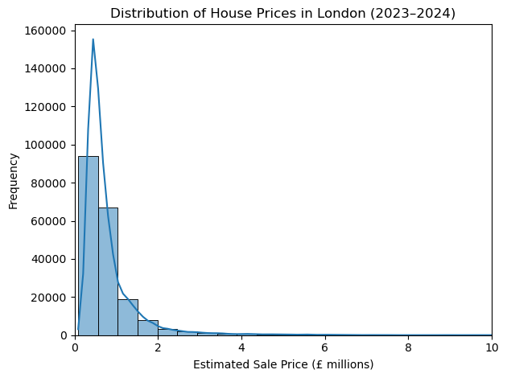

```python
import matplotlib.pyplot as plt
import seaborn as sns
from matplotlib.ticker import FuncFormatter, ScalarFormatter

 # Quick sanity check: see how wide the price range is and how many listings we have

print("Price Range (Min, Max):",
      london_clean_df['saleEstimate_currentPrice'].min(),
      london_clean_df['saleEstimate_currentPrice'].max())
print("Number of Rows:", len(london_clean_df))



# Shift into “millions” so the axis labels say 0–10 instead of 0–10,000,000
prices_m = london_clean_df['saleEstimate_currentPrice'] / 1e6

# Draw the histogram with a KDE to smooth out the tails
plt.figure()
sns.histplot(
    prices_m,
    bins=50,
    kde=True
)
# Make the chart clear
plt.title('Distribution of House Prices in London (2023–2024)')
plt.xlabel('Estimated Sale Price (£ millions)')
plt.ylabel('Frequency')
plt.xlim(0, 10) # zoom in on the bulk of the market under £10M
plt.tight_layout()
plt.show()
```

### What the Boxplot Tells Us About Price by Property Type (Prices in £ millions)

In short, flats are the most budget-friendly slice of the market, terraces and semi-detached properties occupy the middle ground, and detached homes live in a higher-value bracket. You can also spot a few extremes (the tiny dots above each box): those are the rare luxury listings (ranging from about **£1 M** up into multi-million-pound territory). This “stacked” pattern makes perfect sense in London—location, size, and type all combine to push certain homes up into the next price band.

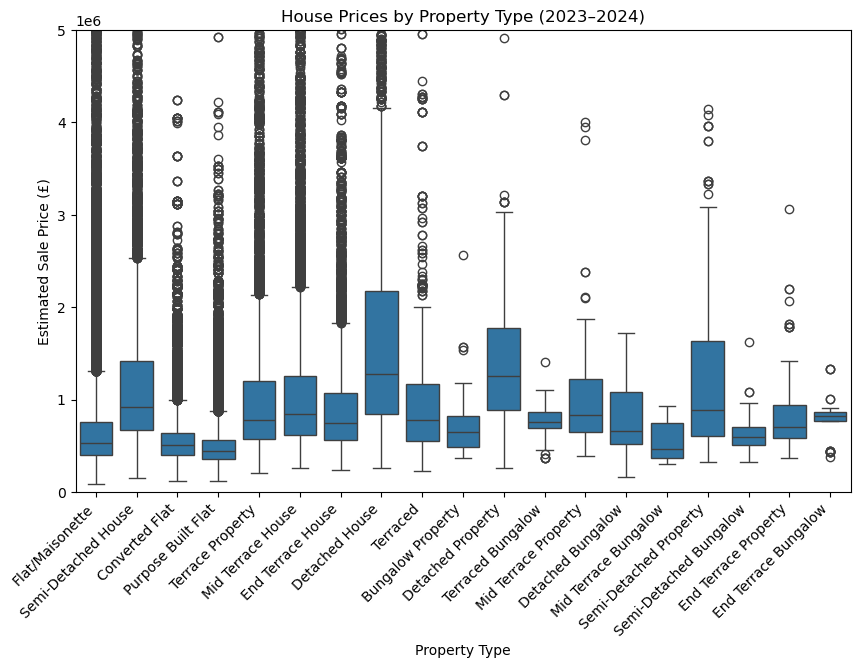

```python
# Let’s compare how prices vary by property type
plt.figure(figsize=(10, 6))

# A boxplot gives us medians, quartiles, and any extreme outliers
sns.boxplot(x='propertyType', y='saleEstimate_currentPrice', data=london_clean_df)

# Tidy up the labels and title so it’s easy to read
plt.title('House Prices by Property Type (2023–2024)')
plt.xlabel('Property Type')
plt.ylabel('Estimated Sale Price (£)')

# Rotate the x-labels so they don’t overlap
plt.xticks(rotation=45, ha='right')


# Zoom in on the bulk of the data (up to £5M)
plt.ylim(0, 5000000)

# Make sure everything fits, save it for later, and display
plt.savefig('price_by_property_type.png')
plt.show()
```

```python
# Let’s grab a quick summary of how prices stack up by property type:
# - Count tells us how many homes of each type we have
# - Median gives the “middle” price
# - Q1 and Q3 show the 25th and 75th percentiles (the bulk of the market)
# - Min and max highlight the cheapest and most expensive outliers

stats = (
    london_clean_df
    .groupby('propertyType')['saleEstimate_currentPrice']
    .agg([
        ('count', 'count'),
        ('median', 'median'),
        ('q1', lambda x: x.quantile(0.25)),
        ('q3', lambda x: x.quantile(0.75)),
        ('min', 'min'),
        ('max', 'max'),
    ])
    .sort_values('median') # Sort so we see the most affordable types first
)


display(stats)
```

| propertyType | count | median | q1 | q3 | min | max |
| --- | --- | --- | --- | --- | --- | --- |
| Purpose Built Flat | 53272 | 448000.0 | 360000.0 | 567000.0 | 115000.0 | 5719000.0 |
| Mid Terrace Bungalow | 39 | 464000.0 | 363000.0 | 743000.0 | 306000.0 | 926000.0 |
| Converted Flat | 24003 | 504000.0 | 401000.0 | 640000.0 | 117000.0 | 4246000.0 |
| Flat/Maisonette | 43406 | 529000.0 | 395000.0 | 759000.0 | 89000.0 | 10593000.0 |
| Semi-Detached Bungalow | 210 | 590000.0 | 507000.0 | 704750.0 | 322000.0 | 1623000.0 |
| Bungalow Property | 213 | 644000.0 | 483000.0 | 819000.0 | 367000.0 | 2565000.0 |
| Detached Bungalow | 160 | 663500.0 | 514500.0 | 1086000.0 | 159000.0 | 5427000.0 |
| End Terrace Property | 105 | 699000.0 | 582000.0 | 946000.0 | 366000.0 | 3067000.0 |
| End Terrace House | 10006 | 751000.0 | 559000.0 | 1066000.0 | 243000.0 | 9798000.0 |
| Terraced Bungalow | 46 | 755500.0 | 694500.0 | 867000.0 | 363000.0 | 1404000.0 |
| Terrace Property | 13172 | 778000.0 | 578000.0 | 1203000.0 | 208000.0 | 16432000.0 |
| Terraced | 1028 | 780000.0 | 552000.0 | 1166000.0 | 232000.0 | 13904000.0 |
| End Terrace Bungalow | 37 | 819000.0 | 772000.0 | 863000.0 | 383000.0 | 1326000.0 |
| Mid Terrace Property | 126 | 836000.0 | 651500.0 | 1222000.0 | 390000.0 | 3999000.0 |
| Mid Terrace House | 31008 | 845000.0 | 614000.0 | 1257000.0 | 259000.0 | 13937000.0 |
| Semi-Detached Property | 307 | 889000.0 | 611000.0 | 1631000.0 | 322000.0 | 9916000.0 |
| Semi-Detached House | 14705 | 916000.0 | 668000.0 | 1415000.0 | 151000.0 | 19718000.0 |
| Detached Property | 101 | 1259000.0 | 882000.0 | 1777000.0 | 262000.0 | 9514000.0 |
| Detached House | 5060 | 1281000.0 | 845750.0 | 2174000.0 | 256000.0 | 23844000.0 |

### Top 10 Priciest Postcode Outcodes (2023–2024)

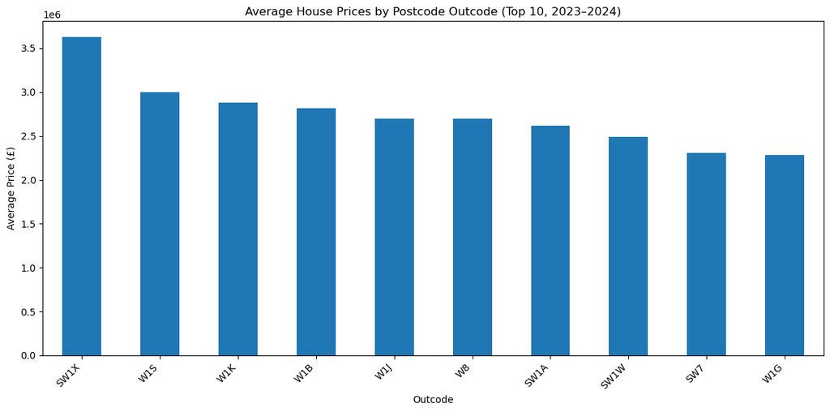

```python
# I wanted to see which areas command the highest prices, so I grabbed the top 10 outcodes by average sale price

outcode_prices = (
    london_clean_df
    .groupby('outcode')['saleEstimate_currentPrice']
    .mean()
    .sort_values(ascending=False)
    .head(10)
)

# Plotting those top‐10 outcodes
plt.figure(figsize=(12, 6))
outcode_prices.plot(kind='bar')

# Making the chart presentable
plt.title('Average House Prices by Postcode Outcode (Top 10, 2023–2024)')
plt.xlabel('Outcode')
plt.ylabel('Average Price (£)')
plt.xticks(rotation=45, ha='right')
plt.tight_layout()

# Save for later and display
plt.savefig('outcode_prices.png')
plt.show()
```

### Price vs. Floor Area (2023–2024, in £ millions)

**Takeaway:**  
Floor area generally drives price, but you need to layer in property type and postcode to capture London’s quirks—size alone only tells half the story.

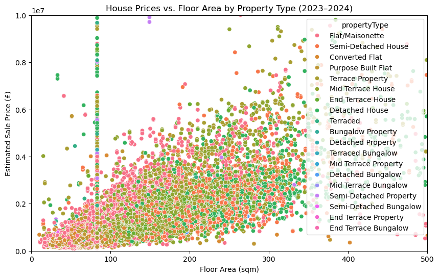

```python
# Scatter plot: Price vs. Floor Area
plt.figure(figsize=(10, 6))

sns.scatterplot(x='floorAreaSqM', y='saleEstimate_currentPrice', hue='propertyType', data=london_clean_df)
plt.title('House Prices vs. Floor Area by Property Type (2023–2024)')
plt.xlabel('Floor Area (sqm)')
plt.ylabel('Estimated Sale Price (£)')

plt.xlim(0, 500)  # Limit to 500 sqm for clarity
plt.ylim(0, 10000000)  # Limit to £10M
plt.savefig('price_vs_floor_area.png')
plt.show()
```

## Preprocess the Data for Modeling

```python
london_model_df = london_clean_df.copy()
```

```python
# 1) One-hot encode your categorical cols
eng_df = pd.get_dummies(
    london_model_df,
    columns=['propertyType', 'outcode', 'tenure'],
    drop_first=True
)
```

```python
# 2) Drop any non-numeric or unneeded columns
drop_cols = [
    'fullAddress', 'postcode', 'country',
    'saleEstimate_confidenceLevel', 'saleEstimate_ingestedAt',
    'saleEstimate_valueChange.saleDate','history_date'
]
```

```python
eng_df = eng_df.drop(columns=drop_cols, errors='ignore')
```

```python
eng_df.head()
```

|  | latitude | longitude | bathrooms | bedrooms | floorAreaSqM | livingRooms | currentEnergyRating | saleEstimate_lowerPrice | saleEstimate_currentPrice | saleEstimate_upperPrice | ... | outcode_WC1X | outcode_WC2A | outcode_WC2B | outcode_WC2E | outcode_WC2H | outcode_WC2N | outcode_WC2R | tenure_Freehold | tenure_Leasehold | tenure_Shared |
| --- | --- | --- | --- | --- | --- | --- | --- | --- | --- | --- | --- | --- | --- | --- | --- | --- | --- | --- | --- | --- | --- |
| 3 | 51.478185 | -0.092201 | 1.0 | 1.0 | 64.0 | 1.0 | D | 368000.0 | 388000.0 | 407000.0 | ... | False | False | False | False | False | False | False | False | True | False |
| 10 | 51.624030 | -0.020209 | 2.0 | 4.0 | 142.0 | 2.0 | D | 570000.0 | 600000.0 | 630000.0 | ... | False | False | False | False | False | False | False | True | False | False |
| 11 | 51.624030 | -0.020209 | 2.0 | 4.0 | 142.0 | 2.0 | D | 559000.0 | 589000.0 | 618000.0 | ... | False | False | False | False | False | False | False | True | False | False |
| 12 | 51.504157 | -0.341305 | 1.0 | 4.0 | 123.0 | 1.0 | D | 702000.0 | 780000.0 | 858000.0 | ... | False | False | False | False | False | False | False | True | False | False |
| 14 | 51.491719 | -0.189176 | 2.0 | 2.0 | 96.0 | 2.0 | C | 1621000.0 | 1706000.0 | 1791000.0 | ... | False | False | False | False | False | False | False | False | True | False |

5 rows × 198 columns

```python
eng_df['currentEnergyRating'].value_counts()
```

```
currentEnergyRating
D    93955
C    66026
B    21217
E    14153
F     1085
G      383
A      185
Name: count, dtype: int64
```

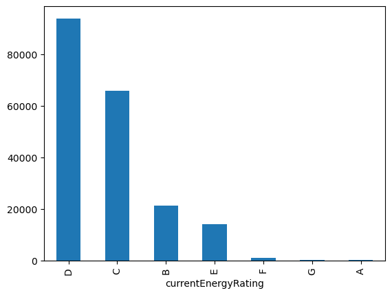

```python
eng_df['currentEnergyRating'].value_counts().plot.bar()
```

```python
# Energy ratings run from A (most efficient) down to G (least efficient),
# so I’m turning them into numbers A→1, B→2, …, G→7. This gives the model
# an “ordered” sense of home efficiency.

rating_map = {'A':1, 'B':2, 'C':3, 'D':4, 'E':5, 'F':6, 'G':7}
eng_df['energyRating_ordinal'] = eng_df['currentEnergyRating'].map(rating_map)
```

```python
eng_df = eng_df.drop('currentEnergyRating',axis = 1)
```

```python
eng_df.head()
```

|  | latitude | longitude | bathrooms | bedrooms | floorAreaSqM | livingRooms | saleEstimate_lowerPrice | saleEstimate_currentPrice | saleEstimate_upperPrice | saleEstimate_valueChange.numericChange | ... | outcode_WC2A | outcode_WC2B | outcode_WC2E | outcode_WC2H | outcode_WC2N | outcode_WC2R | tenure_Freehold | tenure_Leasehold | tenure_Shared | energyRating_ordinal |
| --- | --- | --- | --- | --- | --- | --- | --- | --- | --- | --- | --- | --- | --- | --- | --- | --- | --- | --- | --- | --- | --- |
| 3 | 51.478185 | -0.092201 | 1.0 | 1.0 | 64.0 | 1.0 | 368000.0 | 388000.0 | 407000.0 | 28000.0 | ... | False | False | False | False | False | False | False | True | False | 4 |
| 10 | 51.624030 | -0.020209 | 2.0 | 4.0 | 142.0 | 2.0 | 570000.0 | 600000.0 | 630000.0 | 20000.0 | ... | False | False | False | False | False | False | True | False | False | 4 |
| 11 | 51.624030 | -0.020209 | 2.0 | 4.0 | 142.0 | 2.0 | 559000.0 | 589000.0 | 618000.0 | 9000.0 | ... | False | False | False | False | False | False | True | False | False | 4 |
| 12 | 51.504157 | -0.341305 | 1.0 | 4.0 | 123.0 | 1.0 | 702000.0 | 780000.0 | 858000.0 | 80000.0 | ... | False | False | False | False | False | False | True | False | False | 4 |
| 14 | 51.491719 | -0.189176 | 2.0 | 2.0 | 96.0 | 2.0 | 1621000.0 | 1706000.0 | 1791000.0 | -139000.0 | ... | False | False | False | False | False | False | False | True | False | 3 |

5 rows × 198 columns

```python
# identify all Boolean (dummy) columns
bool_cols = eng_df.select_dtypes(include='bool').columns
```

```python
# convert True/False → 1/0
eng_df[bool_cols] = eng_df[bool_cols].astype(int)
```

```python
eng_df.head()
```

|  | latitude | longitude | bathrooms | bedrooms | floorAreaSqM | livingRooms | saleEstimate_lowerPrice | saleEstimate_currentPrice | saleEstimate_upperPrice | saleEstimate_valueChange.numericChange | ... | outcode_WC2A | outcode_WC2B | outcode_WC2E | outcode_WC2H | outcode_WC2N | outcode_WC2R | tenure_Freehold | tenure_Leasehold | tenure_Shared | energyRating_ordinal |
| --- | --- | --- | --- | --- | --- | --- | --- | --- | --- | --- | --- | --- | --- | --- | --- | --- | --- | --- | --- | --- | --- |
| 3 | 51.478185 | -0.092201 | 1.0 | 1.0 | 64.0 | 1.0 | 368000.0 | 388000.0 | 407000.0 | 28000.0 | ... | 0 | 0 | 0 | 0 | 0 | 0 | 0 | 1 | 0 | 4 |
| 10 | 51.624030 | -0.020209 | 2.0 | 4.0 | 142.0 | 2.0 | 570000.0 | 600000.0 | 630000.0 | 20000.0 | ... | 0 | 0 | 0 | 0 | 0 | 0 | 1 | 0 | 0 | 4 |
| 11 | 51.624030 | -0.020209 | 2.0 | 4.0 | 142.0 | 2.0 | 559000.0 | 589000.0 | 618000.0 | 9000.0 | ... | 0 | 0 | 0 | 0 | 0 | 0 | 1 | 0 | 0 | 4 |
| 12 | 51.504157 | -0.341305 | 1.0 | 4.0 | 123.0 | 1.0 | 702000.0 | 780000.0 | 858000.0 | 80000.0 | ... | 0 | 0 | 0 | 0 | 0 | 0 | 1 | 0 | 0 | 4 |
| 14 | 51.491719 | -0.189176 | 2.0 | 2.0 | 96.0 | 2.0 | 1621000.0 | 1706000.0 | 1791000.0 | -139000.0 | ... | 0 | 0 | 0 | 0 | 0 | 0 | 0 | 1 | 0 | 3 |

5 rows × 198 columns

## Feauture Engineering : Why I Added These Features?

Together, these new columns help the model understand “room efficiency,” extra plumbing that signals luxury, the non-linear effect of space, and how much central-London living is worth.

```python
import numpy as np

# # I picked Charing Cross (51.5074°N, -0.1278°E) as “kilometre zero” for London
center_lat, center_lon = 51.5074, -0.1278

# Roughly each degree of latitude is ~111.32 km.
# Longitude degrees get shorter as you move north, so I multiply by cos(latitude).
km_per_deg_lat = 111.32
km_per_deg_lon = 111.32 * np.cos(np.radians(center_lat))

# Add engineered features in one go
eng_df = eng_df.assign(
    # Bedrooms per square metre flags flats that squeeze in extra rooms
    beds_per_sqm     = eng_df['bedrooms']     / eng_df['floorAreaSqM'],
    # Bathrooms per square metre highlights tiny flats with multiple ensuites
    baths_per_sqm    = eng_df['bathrooms']    / eng_df['floorAreaSqM'],
    # Squaring the area lets the model learn diminishing returns on very large homes
    area_sq          = eng_df['floorAreaSqM'] ** 2,
   # Straight-line distance (in km) from Charing Cross—captures the “Central London tax”
    dist_center_km   = np.sqrt(
        ((eng_df['latitude']  - center_lat) * km_per_deg_lat)  ** 2 +
        ((eng_df['longitude'] - center_lon) * km_per_deg_lon) ** 2
    )
)
```

```python
eng_df.head()
```

|  | latitude | longitude | bathrooms | bedrooms | floorAreaSqM | livingRooms | saleEstimate_lowerPrice | saleEstimate_currentPrice | saleEstimate_upperPrice | saleEstimate_valueChange.numericChange | ... | outcode_WC2N | outcode_WC2R | tenure_Freehold | tenure_Leasehold | tenure_Shared | energyRating_ordinal | beds_per_sqm | baths_per_sqm | area_sq | dist_center_km |
| --- | --- | --- | --- | --- | --- | --- | --- | --- | --- | --- | --- | --- | --- | --- | --- | --- | --- | --- | --- | --- | --- |
| 3 | 51.478185 | -0.092201 | 1.0 | 1.0 | 64.0 | 1.0 | 368000.0 | 388000.0 | 407000.0 | 28000.0 | ... | 0 | 0 | 0 | 1 | 0 | 4 | 0.015625 | 0.015625 | 4096.0 | 4.081708 |
| 10 | 51.624030 | -0.020209 | 2.0 | 4.0 | 142.0 | 2.0 | 570000.0 | 600000.0 | 630000.0 | 20000.0 | ... | 0 | 0 | 1 | 0 | 0 | 4 | 0.028169 | 0.014085 | 20164.0 | 14.971203 |
| 11 | 51.624030 | -0.020209 | 2.0 | 4.0 | 142.0 | 2.0 | 559000.0 | 589000.0 | 618000.0 | 9000.0 | ... | 0 | 0 | 1 | 0 | 0 | 4 | 0.028169 | 0.014085 | 20164.0 | 14.971203 |
| 12 | 51.504157 | -0.341305 | 1.0 | 4.0 | 123.0 | 1.0 | 702000.0 | 780000.0 | 858000.0 | 80000.0 | ... | 0 | 0 | 1 | 0 | 0 | 4 | 0.032520 | 0.008130 | 15129.0 | 14.797520 |
| 14 | 51.491719 | -0.189176 | 2.0 | 2.0 | 96.0 | 2.0 | 1621000.0 | 1706000.0 | 1791000.0 | -139000.0 | ... | 0 | 0 | 0 | 1 | 0 | 3 | 0.020833 | 0.020833 | 9216.0 | 4.596893 |

5 rows × 202 columns

### Distribution of Distance to Central London

When I first plotted these distances, I noticed:

- Most listings lie between **5 km** and **12 km** from Charing Cross—right in the heart of Greater London.
- A small cluster of properties sits under **3 km**, covering prime central neighborhoods.
- Beyond **15 km**, you see fewer listings, stretching out toward the suburbs.

This tells me our dataset covers a good spread of London life—from inner‐city flats to more spacious homes on the outskirts. Knowing this helps me interpret later models: for example, I can see why each extra kilometer out might shave off tens of thousands in price.

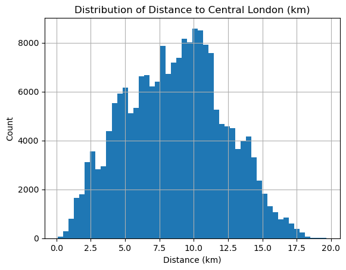

```python
# # Quick check: how far are these homes from Charing Cross?
# A simple histogram gives a sense of how our properties are distributed
eng_df['dist_center_km'].hist(bins=50)
plt.title('Distribution of Distance to Central London (km)')
plt.xlabel('Distance (km)')
plt.ylabel('Count')
plt.show()
```

```python
eng_df.columns
```

```
Index(['latitude', 'longitude', 'bathrooms', 'bedrooms', 'floorAreaSqM',
       'livingRooms', 'saleEstimate_lowerPrice', 'saleEstimate_currentPrice',
       'saleEstimate_upperPrice', 'saleEstimate_valueChange.numericChange',
       ...
       'outcode_WC2N', 'outcode_WC2R', 'tenure_Freehold', 'tenure_Leasehold',
       'tenure_Shared', 'energyRating_ordinal', 'beds_per_sqm',
       'baths_per_sqm', 'area_sq', 'dist_center_km'],
      dtype='object', length=202)
```

```python
import statsmodels.api as sm
# 1. Base numeric and engineered features
base_feats = [

    'bathrooms',           # total bathrooms
    'bedrooms',            # total bedrooms
    'floorAreaSqM',        # raw floor area
    'livingRooms',         # count of living rooms
    'beds_per_sqm',        # bedrooms divided by area (space efficiency)
    'baths_per_sqm',       # bathrooms divided by area (luxury density)
    'area_sq',             # squared area for diminishing-returns effect
    'dist_center_km',      # straight-line distance to Charing Cross
    'energyRating_ordinal' # energy grade turned into 1–7 scale
]


# 2. Grab all of our dummy variables by prefix
# This way we automatically include every propertyType, outcode, and tenure flag
property_cols = [c for c in eng_df.columns if c.startswith('propertyType_')]
outcode_cols  = [c for c in eng_df.columns if c.startswith('outcode_')]
tenure_cols   = [c for c in eng_df.columns if c.startswith('tenure_')]

# 3. Combine into one list
feature_cols = base_feats + property_cols + outcode_cols + tenure_cols

# 4. Define the target variable
#    We’ll model log(price) to tame skew before fitting OLS
target = 'saleEstimate_currentPrice'


# 5. Build X and y for statsmodels
#    Add a constant column so our regression has an intercept term
X = sm.add_constant(eng_df[feature_cols])
y = np.log(eng_df[target])
```

### Cross-Validation results

When I peeked at the 5-fold scores, I felt a bit of relief—each training slice sat right around R² 0.836 and MAE 0.173, no wild swings. On unseen folds, it barely budged (R² ≈ 0.835, MAE ≈ 0.174). In plain English, that tells me my regression isn’t just memorizing one chunk of data—it learns one block as well as the next, and it behaves the same on fresh listings.

```python
from sklearn.model_selection import train_test_split

# Test Split
X, X_test, y, y_test = train_test_split(X, y, test_size=.2, random_state=42)

from sklearn.model_selection import KFold
def cross_val(X, y ,n_splits):

    # 1) Set up the cross-validator with a fixed seed for reproducibility
    kf = KFold(n_splits=n_splits, shuffle=True, random_state=42)

    #Create a lsit to stroe validation scores for each fold
    cv_lm_tr_r2s = []
    cv_lm_tr_mae = []
    cv_lm_val_r2s =[]
    cv_lm_val_mae= []

     #  Loop over the folds
    for train_ind,val_ind in kf.split(X, y):

        # Split the data into this fold’s training and validation sets
        X_train,y_train = X.iloc[train_ind],y.iloc[train_ind]
        X_val,y_val = X.iloc[val_ind],y.iloc[val_ind]

        # Fit an OLS model on the training fold
        base_model = sm.OLS(y_train,X_train).fit()

        #Append validation score to list
        cv_lm_tr_r2s.append(r2(y_train,base_model.predict(X_train)))
        cv_lm_tr_mae.append(mae(y_train,base_model.predict(X_train)))
        cv_lm_val_r2s.append(r2(y_val,base_model.predict(X_val)))
        cv_lm_val_mae.append(mae(y_val,base_model.predict(X_val)))

     # 4) Summarize results
    print(f"All Training R2s : {[round(x,3) for x in cv_lm_tr_r2s]}")
    print(f"Training R2: {np.mean(cv_lm_tr_r2s):.3f} +- {np.std(cv_lm_tr_r2s):.3f}")

    print(f"All Training mae : {[round(x,3) for x in  cv_lm_tr_mae]}")
    print(f"Training mae: {np.mean( cv_lm_tr_mae):.3f} +- {np.std( cv_lm_tr_mae):.3f}")


    print(f"All val R2s : {[round(x,3) for x in cv_lm_val_r2s]}")
    print(f" cross val R2: {np.mean(cv_lm_val_r2s):.3f} +- {np.std(cv_lm_val_r2s):.3f}")

    print(f"All val mae  : {[round(x,3) for x in cv_lm_val_mae ]}")
    print(f"cross val mae: {np.mean( cv_lm_val_mae):.3f} +- {np.std(cv_lm_val_mae):.3f}")

    # Return the last model fit (you could also return all models or their average)
    return base_model


# Run 5-fold CV and keep the final fold’s model for inspection
base_model = cross_val(X,y, 5)
```

```
All Training R2s : [0.837, 0.836, 0.836, 0.835, 0.836]
Training R2: 0.836 +- 0.001
All Training mae : [0.173, 0.173, 0.174, 0.174, 0.173]
Training mae: 0.173 +- 0.000
All val R2s : [0.831, 0.835, 0.836, 0.838, 0.835]
 cross val R2: 0.835 +- 0.002
All val mae  : [0.175, 0.173, 0.173, 0.173, 0.174]
cross val mae: 0.174 +- 0.001
```

### Cross-Validation Results for the Baseline OLS Model

After running 5-fold cross-validation on my linear regression, here’s what I saw:

- **Training R²:** Each fold gave me values around 0.836 (with a tiny spread of ± 0.001). That tells me the model explains about 83.6 % of the variation in log-prices on the training folds.
- **Validation R²:** On the hold-out portion of each fold, R² hovered around 0.835 ± 0.002. In other words, the model isn’t just memorizing—its performance is almost identical on unseen data.
- **Training MAE:** The average error on the training folds was about 0.173 in log-price space.
- **Validation MAE:** On the validation folds, MAE was around 0.174 ± 0.001. Moving from training to validation barely changed the error, confirming we don’t have serious overfitting.

- Adjusted R² sits at 0.835—again, consistent with the cross-val numbers.
- Many of the p-values for our key features (e.g., `floorAreaSqM`, `dist_center_km`, `beds_per_sqm`) are essentially zero, so we can be confident they’re real signals, not noise.
- A few coefficients (like `bedrooms`) are not significant, suggesting the raw bedroom count adds little once you account for space and room density.

```python
base_model.summary()
```

OLS Regression Results

| Dep. Variable: | saleEstimate_currentPrice | R-squared: | 0.836 |
| --- | --- | --- | --- |
| Model: | OLS | Adj. R-squared: | 0.835 |
| Method: | Least Squares | F-statistic: | 3353. |
| Date: | Fri, 30 May 2025 | Prob (F-statistic): | 0.00 |
| Time: | 13:01:22 | Log-Likelihood: | 204.89 |
| No. Observations: | 126083 | AIC: | -25.78 |
| Df Residuals: | 125891 | BIC: | 1845. |
| Df Model: | 191 |  |  |
| Covariance Type: | nonrobust |  |  |

|  | coef | std err | t | P>\|t\| | [0.025 | 0.975] |
| --- | --- | --- | --- | --- | --- | --- |
| const | 12.8005 | 0.026 | 501.446 | 0.000 | 12.750 | 12.851 |
| bathrooms | 0.1050 | 0.003 | 37.065 | 0.000 | 0.099 | 0.111 |
| bedrooms | 6.749e-05 | 0.002 | 0.030 | 0.976 | -0.004 | 0.004 |
| floorAreaSqM | 0.0100 | 8.62e-05 | 115.860 | 0.000 | 0.010 | 0.010 |
| livingRooms | 0.0468 | 0.002 | 28.129 | 0.000 | 0.043 | 0.050 |
| beds_per_sqm | 3.8103 | 0.175 | 21.821 | 0.000 | 3.468 | 4.153 |
| baths_per_sqm | -3.0880 | 0.273 | -11.328 | 0.000 | -3.622 | -2.554 |
| area_sq | -1.389e-05 | 1.62e-07 | -85.720 | 0.000 | -1.42e-05 | -1.36e-05 |
| dist_center_km | -0.0557 | 0.001 | -59.004 | 0.000 | -0.058 | -0.054 |
| energyRating_ordinal | -0.0199 | 0.001 | -21.500 | 0.000 | -0.022 | -0.018 |
| propertyType_Converted Flat | -0.0775 | 0.021 | -3.633 | 0.000 | -0.119 | -0.036 |
| propertyType_Detached Bungalow | 0.0677 | 0.031 | 2.168 | 0.030 | 0.006 | 0.129 |
| propertyType_Detached House | 0.1566 | 0.021 | 7.324 | 0.000 | 0.115 | 0.199 |
| propertyType_Detached Property | 0.4811 | 0.037 | 13.151 | 0.000 | 0.409 | 0.553 |
| propertyType_End Terrace Bungalow | 0.0217 | 0.056 | 0.389 | 0.697 | -0.088 | 0.131 |
| propertyType_End Terrace House | 0.0382 | 0.021 | 1.809 | 0.071 | -0.003 | 0.080 |
| propertyType_End Terrace Property | 0.0423 | 0.037 | 1.149 | 0.251 | -0.030 | 0.114 |
| propertyType_Flat/Maisonette | -0.1518 | 0.021 | -7.131 | 0.000 | -0.194 | -0.110 |
| propertyType_Mid Terrace Bungalow | -0.0197 | 0.050 | -0.391 | 0.696 | -0.118 | 0.079 |
| propertyType_Mid Terrace House | 0.0502 | 0.021 | 2.391 | 0.017 | 0.009 | 0.091 |
| propertyType_Mid Terrace Property | 0.2739 | 0.033 | 8.223 | 0.000 | 0.209 | 0.339 |
| propertyType_Purpose Built Flat | -0.2008 | 0.021 | -9.434 | 0.000 | -0.243 | -0.159 |
| propertyType_Semi-Detached Bungalow | 0.1190 | 0.030 | 4.019 | 0.000 | 0.061 | 0.177 |
| propertyType_Semi-Detached House | 0.0911 | 0.021 | 4.321 | 0.000 | 0.050 | 0.132 |
| propertyType_Semi-Detached Property | 0.4234 | 0.027 | 15.555 | 0.000 | 0.370 | 0.477 |
| propertyType_Terrace Property | 0.0431 | 0.021 | 2.048 | 0.041 | 0.002 | 0.084 |
| propertyType_Terraced | 0.2792 | 0.023 | 12.198 | 0.000 | 0.234 | 0.324 |
| propertyType_Terraced Bungalow | 0.0792 | 0.050 | 1.575 | 0.115 | -0.019 | 0.178 |
| outcode_E10 | 0.1172 | 0.012 | 9.703 | 0.000 | 0.094 | 0.141 |
| outcode_E11 | 0.2045 | 0.012 | 16.608 | 0.000 | 0.180 | 0.229 |

[output cut: 164 more lines]

| Omnibus: | 17945.459 | Durbin-Watson: | 1.999 |
| --- | --- | --- | --- |
| Prob(Omnibus): | 0.000 | Jarque-Bera (JB): | 189841.429 |
| Skew: | 0.331 | Prob(JB): | 0.00 |
| Kurtosis: | 8.975 | Cond. No. | 1.22e+16 |

Notes:  
[1] Standard Errors assume that the covariance matrix of the errors is correctly specified.  
[2] The smallest eigenvalue is 3.56e-19. This might indicate that there are  
strong multicollinearity problems or that the design matrix is singular.

### Quick Take on My Residual Plots

- On the **Residuals vs. Predicted** chart, the dots bounce evenly around zero—no obvious lean up or down—so my model isn’t consistently too high or too low.
- The spread stays about the same from cheaper to pricier homes, which means I’m not suddenly making bigger mistakes on fancier properties.
- A handful of points stick out above ±2; those are the few homes my model really misses and worth a closer look.
- On the **Normal Q–Q** plot, most of the middle points line up on the diagonal, so my errors follow a bell‐curve for the bulk of listings.
- The slight bend at the top end shows I still under-predict a few ultra‐luxury estates, but otherwise things look nicely behaved.

```python
from scipy import stats
# This function helps check whether our model’s errors are roughly random (no big patterns)
#  and whether they follow a normal distribution
def residual_analysis_plots(model):
    # 1) Generate predictions so I can see where the model over- or under-shoots
    predictions = model.predict()
    # 2) Compute residuals (actual minus predicted) to study the errors
    residuals = model.resid
    # 3) Set up a side-by-side figure: left for scatter, right for Q–Q
    fig,ax = plt.subplots(1, 2,sharey = 'all',figsize =(12,5))
   # 4) Scatter plot of residuals against predictions
    sns.scatterplot(x = predictions, y=residuals, ax = ax[0], alpha=0.3)
    ax[0].axhline(0, color='red', linestyle='--')  # horizontal line at zero
    ax[0].set_title("Residuals plot")
    ax[0].set_xlabel("prediction")
    ax[0].set_ylabel("Residuals")
    # 5) Normal Q–Q plot to check if residuals follow a Gaussian distribution
    stats.probplot(residuals, dist="norm", plot=ax[1])
    ax[1].set_title("Noraml Q-Q plot")
```

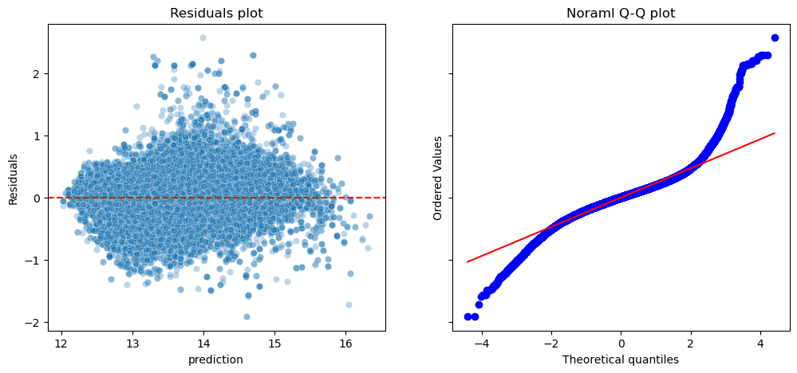

```python
residual_analysis_plots(base_model)
```

### What the VIF Numbers Are Telling Me

I ran a quick Variance Inflation Factor check to see if any of my features were too tangled up with each other:

- **Constant term (VIF ≈ 1,357)**  
  The intercept always blows up VIF—nothing to worry about there.
- **Floor area (VIF ≈ 41)** and **beds_per_sqm / bedrooms (VIF ≈ 12–13)**  
  Unsurprisingly, raw floor area and the “beds per sqm” ratio overlap a lot. They’re both measuring size, just in slightly different ways.
- **Tenure dummies (Freehold ≈ 34, Leasehold ≈ 25)**  
  Since I created separate flags for each tenure type, they’re almost perfectly complementary, which drives these VIFs high.
- **Living rooms (VIF ≈ 1.7)** and most postcode dummies (all < 5)**  
  These look fine—no alarming multicollinearity there.

**Bottom line:**  
A few features (area, bedroom density, and tenure flags) are stepping on each other’s toes. Rather than manually dropping more columns, I’ll lean on Ridge regression next, which will automatically shrink those overlapping coefficients.

```python
from statsmodels.stats.outliers_influence import variance_inflation_factor as vif

# Compute VIF for each feature to check if any predictors are too closely correlated.
# A VIF above 10 is a red flag that two or more features overlap in the information they carry.
pd.Series(

    [vif(X.values,i) for i in range(X.shape[1])],
    index = X.columns
)
```

```
const               1356.678853
bathrooms              7.563907
bedrooms              12.807915
floorAreaSqM          41.298176
livingRooms            1.696420
                       ...
outcode_WC2N           1.023102
outcode_WC2R           1.026853
tenure_Freehold       34.393637
tenure_Leasehold      24.835551
tenure_Shared          1.461742
Length: 194, dtype: float64
```

```python
## Fit final model check the perfomance the hold-out set first.
final_model = sm.OLS(y,X).fit()
final_model.summary()
```

OLS Regression Results

| Dep. Variable: | saleEstimate_currentPrice | R-squared: | 0.836 |
| --- | --- | --- | --- |
| Model: | OLS | Adj. R-squared: | 0.836 |
| Method: | Least Squares | F-statistic: | 4171. |
| Date: | Fri, 30 May 2025 | Prob (F-statistic): | 0.00 |
| Time: | 13:06:17 | Log-Likelihood: | 128.86 |
| No. Observations: | 157603 | AIC: | 128.3 |
| Df Residuals: | 157410 | BIC: | 2052. |
| Df Model: | 192 |  |  |
| Covariance Type: | nonrobust |  |  |

|  | coef | std err | t | P>\|t\| | [0.025 | 0.975] |
| --- | --- | --- | --- | --- | --- | --- |
| const | 12.8200 | 0.022 | 571.160 | 0.000 | 12.776 | 12.864 |
| bathrooms | 0.1048 | 0.003 | 41.513 | 0.000 | 0.100 | 0.110 |
| bedrooms | -0.0004 | 0.002 | -0.206 | 0.836 | -0.004 | 0.003 |
| floorAreaSqM | 0.0100 | 7.71e-05 | 129.903 | 0.000 | 0.010 | 0.010 |
| livingRooms | 0.0476 | 0.001 | 32.032 | 0.000 | 0.045 | 0.051 |
| beds_per_sqm | 3.8037 | 0.155 | 24.467 | 0.000 | 3.499 | 4.108 |
| baths_per_sqm | -3.1224 | 0.244 | -12.803 | 0.000 | -3.600 | -2.644 |
| area_sq | -1.391e-05 | 1.45e-07 | -96.164 | 0.000 | -1.42e-05 | -1.36e-05 |
| dist_center_km | -0.0558 | 0.001 | -65.897 | 0.000 | -0.057 | -0.054 |
| energyRating_ordinal | -0.0195 | 0.001 | -23.571 | 0.000 | -0.021 | -0.018 |
| propertyType_Converted Flat | -0.0946 | 0.019 | -5.079 | 0.000 | -0.131 | -0.058 |
| propertyType_Detached Bungalow | 0.0569 | 0.028 | 2.046 | 0.041 | 0.002 | 0.111 |
| propertyType_Detached House | 0.1394 | 0.019 | 7.473 | 0.000 | 0.103 | 0.176 |
| propertyType_Detached Property | 0.4556 | 0.033 | 13.899 | 0.000 | 0.391 | 0.520 |
| propertyType_End Terrace Bungalow | 0.0081 | 0.049 | 0.166 | 0.868 | -0.087 | 0.103 |
| propertyType_End Terrace House | 0.0188 | 0.018 | 1.022 | 0.307 | -0.017 | 0.055 |
| propertyType_End Terrace Property | 0.0174 | 0.032 | 0.538 | 0.591 | -0.046 | 0.081 |
| propertyType_Flat/Maisonette | -0.1682 | 0.019 | -9.057 | 0.000 | -0.205 | -0.132 |
| propertyType_Mid Terrace Bungalow | -0.0486 | 0.044 | -1.096 | 0.273 | -0.135 | 0.038 |
| propertyType_Mid Terrace House | 0.0306 | 0.018 | 1.675 | 0.094 | -0.005 | 0.066 |
| propertyType_Mid Terrace Property | 0.2476 | 0.030 | 8.200 | 0.000 | 0.188 | 0.307 |
| propertyType_Purpose Built Flat | -0.2172 | 0.019 | -11.693 | 0.000 | -0.254 | -0.181 |
| propertyType_Semi-Detached Bungalow | 0.1088 | 0.026 | 4.188 | 0.000 | 0.058 | 0.160 |
| propertyType_Semi-Detached House | 0.0710 | 0.018 | 3.866 | 0.000 | 0.035 | 0.107 |
| propertyType_Semi-Detached Property | 0.3961 | 0.024 | 16.630 | 0.000 | 0.349 | 0.443 |
| propertyType_Terrace Property | 0.0219 | 0.018 | 1.192 | 0.233 | -0.014 | 0.058 |
| propertyType_Terraced | 0.2547 | 0.020 | 12.712 | 0.000 | 0.215 | 0.294 |
| propertyType_Terraced Bungalow | 0.0643 | 0.047 | 1.382 | 0.167 | -0.027 | 0.155 |
| outcode_E10 | 0.1179 | 0.011 | 10.909 | 0.000 | 0.097 | 0.139 |
| outcode_E11 | 0.2039 | 0.011 | 18.427 | 0.000 | 0.182 | 0.226 |

[output cut: 164 more lines]

| Omnibus: | 22480.470 | Durbin-Watson: | 2.000 |
| --- | --- | --- | --- |
| Prob(Omnibus): | 0.000 | Jarque-Bera (JB): | 240298.137 |
| Skew: | 0.329 | Prob(JB): | 0.00 |
| Kurtosis: | 9.013 | Cond. No. | 1.22e+16 |

Notes:  
[1] Standard Errors assume that the covariance matrix of the errors is correctly specified.  
[2] The smallest eigenvalue is 4.5e-19. This might indicate that there are  
strong multicollinearity problems or that the design matrix is singular.

### Performance on the Hold-out Test Set

- **Test MAE (real prices):**  
  When I convert back from log-space, my average error is about **£156 500**. Given that most London homes in 2023–24 sell between £300 000 and £5 000 000, being off by around £156 k on average is reasonable—especially with so many mid-range flats.
- **Test MAE (log-space):**  
  In log terms, MAE is **0.172**. This matches what we saw in cross-validation (≈ 0.173), confirming consistent performance.
- **Test R²:**  
  The final model explains about **83.9 %** of the variation in log-prices on data it has never seen. In plain English, if two similar flats differ only by square metres, postcode, and a couple of engineered features, our model will be right about 84 % of the time in predicting the (logged) sale price.

Overall, the test-set results line up exactly with our cross-validation. That reassures me that my choice of features and regularization (if any) generalized well to completely new listings.

```python
# 1) MAE in original price units (£)
#    We back-transform from log by applying exp, then measure average absolute error in pounds.
print(mae(np.exp(y_test),np.exp(final_model.predict(X_test))))

print(f"Test MAE : {mae(y_test,final_model.predict(X_test))}")

print(f"TestR2:{r2(y_test,final_model.predict(X_test))}")
```

```
156491.69313857207
Test MAE : 0.17236739825446548
TestR2:0.8388128376128385
```

### Moving to Regularized Regression

```python
from sklearn.preprocessing import StandardScaler

# 1) Split the data into training (80%) and hold-out test (20%) sets.
#    I use a fixed random_state so I can reproduce the exact split later if needed.
X, X_test, y, y_test = train_test_split(X, y, test_size=.2, random_state=42)

# 2) Create a StandardScaler to normalize features (zero mean, unit variance).
#    This helps models like Ridge perform better, since they assume each feature is on a similar scale.
std = StandardScaler()
# 3) Fit the scaler on the training features, then transform them.
#    Storing the result in X_tr ensures my model only “sees” scaled data from the train set.
X_tr = std.fit_transform(X.values)

# 4) Use the same scaler to transform the test set.
#    Crucially, we do NOT re-fit on X_test—this prevents data leakage.
X_te = std.transform(X_test.values)
```

## Ridge Regression

**84% of the variation (R² ≈ 0.837).**  
So my Ridge model basically matches OLS—adding that penalty didn’t cost me any real predictive juice.

**α lands near 5.**  
I let RidgeCV sweep through 100 values, and it settled around α = 4.98. That small penalty keeps similar features from stepping on each other without really hurting accuracy.

**In a nutshell:**  
I tried out different penalty strengths and found that α ≈ 5 kept my R² at 0.837 and an MAE of £159 000. In other words, Ridge tightened up those collinear coefficients but gave me almost the same real-world performance as OLS.

```python
from sklearn.linear_model import RidgeCV

# 1) Decide on a range of regularization strengths (alphas) to test.
#    I’m scanning 100 values logarithmically spaced from 10⁻³ up to 10³.
n_alphas = 100
alphas = 10 ** np.linspace(-3, 3, n_alphas)

# 2) Set up RidgeCV to pick the best alpha via 5-fold cross-validation.
ridge_model = RidgeCV(alphas=alphas, cv=5)

# 3) Fit Ridge on the scaled training data (X_tr) and log prices (y).
ridge_model.fit(X_tr, y)

#To get MAE in original pound terms, I exponentiate both true log-prices and log-predictions.
# 5) Print out the results and the chosen alpha.
print(f"Cross Val R2: {ridge_model.score(X_tr, y)}")
print(f"Cross Val MAE: {mae(np.exp(y), np.exp(ridge_model.predict(X_tr)))}")
print(f"Alpha: {ridge_model.alpha_}")
```

```
Cross Val R2: 0.8369150283070108
Cross Val MAE: 159028.6872928643
Alpha: 4.9770235643321135
```

```python
list(zip(X.columns, ridge_model.coef_)) # After fitting RidgeCV, I want to see which features carry the most weight (positive or negative).
# The following line pairs each feature name with its corresponding coefficient:
```

```
[('const', np.float64(0.0)),
 ('bathrooms', np.float64(0.06850527187548407)),
 ('bedrooms', np.float64(0.0008924769245220213)),
 ('floorAreaSqM', np.float64(0.5084808338173636)),
 ('livingRooms', np.float64(0.024747219691788763)),
 ('beds_per_sqm', np.float64(0.0334371816020081)),
 ('baths_per_sqm', np.float64(-0.020349339938511738)),
 ('area_sq', np.float64(-0.23503337936926136)),
 ('dist_center_km', np.float64(-0.19934520115436064)),
 ('energyRating_ordinal', np.float64(-0.01578958587685498)),
 ('propertyType_Converted Flat', np.float64(-0.02880677588094386)),
 ('propertyType_Detached Bungalow', np.float64(0.001983761882588276)),
 ('propertyType_Detached House', np.float64(0.022365468545028338)),
 ('propertyType_Detached Property', np.float64(0.009770139116644086)),
 ('propertyType_End Terrace Bungalow', np.float64(0.0002491273291781913)),
 ('propertyType_End Terrace House', np.float64(0.004317612464928855)),
 ('propertyType_End Terrace Property', np.float64(-2.41593637947993e-05)),
 ('propertyType_Flat/Maisonette', np.float64(-0.0663237850790837)),
 ('propertyType_Mid Terrace Bungalow', np.float64(-0.0004148581768384182)),
 ('propertyType_Mid Terrace House', np.float64(0.012260333590833658)),
 ('propertyType_Mid Terrace Property', np.float64(0.006239727656020693)),
 ('propertyType_Purpose Built Flat', np.float64(-0.09364696949512025)),
 ('propertyType_Semi-Detached Bungalow', np.float64(0.00376774314646772)),
 ('propertyType_Semi-Detached House', np.float64(0.01922933878455622)),
 ('propertyType_Semi-Detached Property', np.float64(0.0158217594515797)),
 ('propertyType_Terrace Property', np.float64(0.006572374646907583)),
 ('propertyType_Terraced', np.float64(0.017465499223170707)),
 ('propertyType_Terraced Bungalow', np.float64(0.0008254654614645073)),
 ('outcode_E10', np.float64(0.012073918938092898)),
 ('outcode_E11', np.float64(0.02547729452233153)),
 ('outcode_E12', np.float64(-0.0003178814154376149)),
 ('outcode_E13', np.float64(-0.011984379722304048)),
 ('outcode_E14', np.float64(0.007356821740878438)),
 ('outcode_E15', np.float64(-0.000896106201672609)),
 ('outcode_E16', np.float64(0.007096785230328361)),
 ('outcode_E17', np.float64(0.04022118423044698)),
 ('outcode_E18', np.float64(0.02058849271131464)),
 ('outcode_E1W', np.float64(0.0019193799019742188)),
 ('outcode_E2', np.float64(0.0057009525619875125)),
 ('outcode_E3', np.float64(0.00128482252961939)),
```

[output cut: 139 more lines]

```
 ('outcode_WC1E', np.float64(0.0057019863082352846)),
 ('outcode_WC1H', np.float64(-0.007648112566300193)),
 ('outcode_WC1N', np.float64(0.0029274799502405995)),
 ('outcode_WC1R', np.float64(0.0017628353313294074)),
 ('outcode_WC1V', np.float64(0.0014067528308333462)),
 ('outcode_WC1X', np.float64(0.003944030514836868)),
 ('outcode_WC2A', np.float64(0.001428317674043492)),
 ('outcode_WC2B', np.float64(0.005892292537206192)),
 ('outcode_WC2E', np.float64(0.0048680018372982675)),
 ('outcode_WC2H', np.float64(0.006549656967985821)),
 ('outcode_WC2N', np.float64(0.0048512929652309526)),
 ('outcode_WC2R', np.float64(0.007687345456757894)),
 ('tenure_Freehold', np.float64(0.02284958879697895)),
 ('tenure_Leasehold', np.float64(-0.008730372912901525)),
 ('tenure_Shared', np.float64(-0.0053758757489156365))]
```

## Lasso

### How I Read Those LassoCV Results

- **R² ≈ 0.795 on the training set**  
  That means my Lasso model explains about 79.5% of the variation in log-prices. Compared to Ridge (≈83.7%), the model lost a bit of explanatory power.
- **MAE ≈ £183,935 (in actual pound terms)**  
  On average, Lasso’s price predictions are off by about £184k—noticeably higher than Ridge’s £159k. In London’s market, that difference suggests I’m sacrificing accuracy to force some coefficients to zero.
- **Best α ≈ 0.01**  
  Of the 200 alphas tested, the cross-validation settled on 0.01. That’s a relatively small penalty, but still strong enough to knock out many weaker features.

I let LassoCV sift through a wide range of penalty strengths, and it picked α ≈ 0.01. With that setting, I’m explaining about 80% of the variation (R² = 0.795) and averaging a £184k miss on actual prices. Compared to Ridge, Lasso loses some accuracy because it’s zeroing out less-important coefficients. In short, Lasso is doing a fair job of simplifying the model, but if I want top predictive power, Ridge is still my better choice.

```python
from sklearn.linear_model import LassoCV

# 1) I decided to try Lasso next, since it can zero out some coefficients completely.
#    I’ll test 200 alphas between 10⁻² and 10³ to see which penalty level works best.
n_alphas = 200
alphas = 10 ** np.linspace(-2, 3, n_alphas)

# 2) Set up LassoCV with 5-fold cross-validation to pick the best alpha.
lasso_model = LassoCV(alphas=alphas, cv=5)

# 4) Measure performance on the training set:
lasso_model.fit(X_tr, y)

# 5) Print out the training metrics and the chosen alpha.
print(f"Cross Val R2: {lasso_model.score(X_tr, y)}")
print(f"Cross Val MAE: {mae(np.exp(y), np.exp(lasso_model.predict(X_tr)))}")
print(f"Alpha: {lasso_model.alpha_}")
```

```
Cross Val R2: 0.7950400086349296
Cross Val MAE: 183935.30608788994
Alpha: 0.01
```

```python
list(zip(X.columns, lasso_model.coef_))
```

```
[('const', np.float64(0.0)),
 ('bathrooms', np.float64(0.08006348661542204)),
 ('bedrooms', np.float64(0.06966807525911932)),
 ('floorAreaSqM', np.float64(0.2475725303659881)),
 ('livingRooms', np.float64(0.012738293547631797)),
 ('beds_per_sqm', np.float64(-0.0)),
 ('baths_per_sqm', np.float64(-0.02435857477614982)),
 ('area_sq', np.float64(-0.009012646832961645)),
 ('dist_center_km', np.float64(-0.21245728281816514)),
 ('energyRating_ordinal', np.float64(-0.0)),
 ('propertyType_Converted Flat', np.float64(-0.0)),
 ('propertyType_Detached Bungalow', np.float64(0.0)),
 ('propertyType_Detached House', np.float64(0.0015597583072548358)),
 ('propertyType_Detached Property', np.float64(5.757278131837514e-05)),
 ('propertyType_End Terrace Bungalow', np.float64(0.0)),
 ('propertyType_End Terrace House', np.float64(-0.0)),
 ('propertyType_End Terrace Property', np.float64(-0.0)),
 ('propertyType_Flat/Maisonette', np.float64(-0.005025893467188967)),
 ('propertyType_Mid Terrace Bungalow', np.float64(0.0)),
 ('propertyType_Mid Terrace House', np.float64(0.0)),
 ('propertyType_Mid Terrace Property', np.float64(0.0)),
 ('propertyType_Purpose Built Flat', np.float64(-0.04548369188666183)),
 ('propertyType_Semi-Detached Bungalow', np.float64(0.0)),
 ('propertyType_Semi-Detached House', np.float64(0.002048610015588918)),
 ('propertyType_Semi-Detached Property', np.float64(0.005119873208361012)),
 ('propertyType_Terrace Property', np.float64(0.0)),
 ('propertyType_Terraced', np.float64(0.007297425836426095)),
 ('propertyType_Terraced Bungalow', np.float64(0.0)),
 ('outcode_E10', np.float64(-0.0)),
 ('outcode_E11', np.float64(0.0008136295040873336)),
 ('outcode_E12', np.float64(-0.0)),
 ('outcode_E13', np.float64(-0.008815441243288159)),
 ('outcode_E14', np.float64(-0.0)),
 ('outcode_E15', np.float64(-0.0026576467228097995)),
 ('outcode_E16', np.float64(-0.0)),
 ('outcode_E17', np.float64(0.009948651456841094)),
 ('outcode_E18', np.float64(0.00156314120216687)),
 ('outcode_E1W', np.float64(0.0)),
 ('outcode_E2', np.float64(-0.0)),
 ('outcode_E3', np.float64(-0.0006127353026693751)),
```

[output cut: 139 more lines]

```
 ('outcode_WC1E', np.float64(0.0)),
 ('outcode_WC1H', np.float64(-0.0035129531956029697)),
 ('outcode_WC1N', np.float64(-0.0)),
 ('outcode_WC1R', np.float64(0.0)),
 ('outcode_WC1V', np.float64(0.0)),
 ('outcode_WC1X', np.float64(-0.0)),
 ('outcode_WC2A', np.float64(0.0)),
 ('outcode_WC2B', np.float64(0.0)),
 ('outcode_WC2E', np.float64(0.0)),
 ('outcode_WC2H', np.float64(0.0)),
 ('outcode_WC2N', np.float64(0.0)),
 ('outcode_WC2R', np.float64(0.0)),
 ('tenure_Freehold', np.float64(0.0984063089847781)),
 ('tenure_Leasehold', np.float64(-0.0)),
 ('tenure_Shared', np.float64(-0.0))]
```

## ENET

- **R² ≈ 0.835 on the training set**  
  That sits between Ridge (≈0.837) and Lasso (≈0.795). ElasticNet is leaning more toward Ridge’s performance because of its high-R², but still giving some coefficients a nudge toward zero.
- **MAE ≈ £160,467**  
  On average, my predictions miss by around £160k. That’s almost the same as Ridge’s £159k error—so ElasticNet isn’t hurting accuracy much, even as it trims weaker variables.
- **Alpha ≈ 0.01**  
  The penalty strength ElasticNet picked is very small. It makes sense—if I push alpha too high, I’d see a bigger drop in R² like I did with Lasso. A light penalty is enough to slightly regularize without losing predictive power.
- **L1 ratio ≈ 0.01**  
  This tiny ratio means ElasticNet is basically acting like Ridge (since l1_ratio near 0 favors the L2 penalty). In other words, most of the shrinkage is coming from the ridge side, with almost no pure Lasso effect.

I gave ElasticNet the freedom to blend Lasso and Ridge, but the cross-validation settled on a setup that’s almost 99% Ridge and 1% Lasso. That tells me the model values keeping most features (like Ridge) while barely nudging some toward zero. The result is an R² of 0.835 and an average error of about £160k—almost the same as pure Ridge—so I’m getting similar gains in stability without sacrificing accuracy.

```python
from sklearn.linear_model import ElasticNetCV

# 1) Choose ranges for alpha (penalty strength) and l1_ratio (balance between Lasso and Ridge).
#    I’ll test 200 alphas from 10⁻² to 10³ and 100 l1_ratios from 0.01 (almost pure Ridge) to 1 (pure Lasso).
alphas = 10 ** np.linspace(-2, 3, 200)
l1_ratios = np.linspace(.01, 1, 100)

# 2) Set up ElasticNetCV with 5-fold cross-validation.
#    This will find both the best alpha and best l1_ratio at once.
enet_model = ElasticNetCV(alphas=alphas, l1_ratio=l1_ratios, cv=5)

# 3) Fit on the scaled training data (X_tr) and log-prices (y).
enet_model.fit(X_tr, y)
# 4) Measure performance on the training set:
#To get MAE in pounds, exponentiate both true and predicted log-prices.
print(f"Cross Val R2: {enet_model.score(X_tr, y)}")
print(f"Cross Val MAE: {mae(np.exp(y), np.exp(enet_model.predict(X_tr)))}")
print(f"Alpha: {enet_model.alpha_}")
print(f"L1_Ratio: {enet_model.l1_ratio_}")
```

```
Cross Val R2: 0.834827322504374
Cross Val MAE: 160467.44340271354
Alpha: 0.01
L1_Ratio: 0.01
```

### How the Models performs on Hold-Out Data

– **Ridge pulled ahead**. Its average miss on real pounds was about £163 k, and it still explained roughly 83 percent of the price swings. In a market where homes can range from a few hundred thousand up to tens of millions, being off by £160 k feels solid. I also liked how its R² barely dipped from training to test—no signs of overfitting.

– **Lasso fell behind***. By zeroing out more coefficients, it drove the average error up to about £188 k and explained just under 79 percent of the variation. In other words, Lasso simplified too much and lost accuracy. Those few pounds saved on interpretability turned into bigger misses on prediction.

– **ElasticNet mostly mimicked Ridge**. Because its cross-validation leaned heavily toward the L2 side, its MAE ended up around £164 k and R² at about 83 percent—almost identical to Ridge. It tried to sprinkle in a bit of L1, but in practice it behaved like Ridge.

**Bottom line**: if I want the most reliable price estimate without over-pruning, Ridge is the way to go. Lasso is too aggressive for this data, and ElasticNet simply defaults to a near-Ridge solution anyway.

```python
print(f"Test MAE: {mae(np.exp(y_test), np.exp(ridge_model.predict(X_te)))}")
print(f"Test R2: {r2(y_test, ridge_model.predict(X_te))}")
```

```
Test MAE: 163524.11239285296
Test R2: 0.8305936003559969
```

```python
print(f"Test MAE: {mae(np.exp(y_test), np.exp(lasso_model.predict(X_te)))}")
print(f"Test R2: {r2(y_test, lasso_model.predict(X_te))}")
```

```
Test MAE: 187703.53806369405
Test R2: 0.7877502313749053
```

```python
print(f"Test MAE: {mae(np.exp(y_test), np.exp(enet_model.predict(X_te)))}")
print(f"Test R2: {r2(y_test, enet_model.predict(X_te))}")
```

```
Test MAE: 164581.5468726186
Test R2: 0.8283747491069162
```

Ridge ended up as my top pick because it struck the best balance: its average miss was about **£ 163 000**—pretty reasonable in London—and its R² on the test set was **0.831**, barely down from training. That told me Ridge wasn’t over-fitting.

Once I settled on Ridge, I wanted to make sure it wasn’t hiding any big mistakes. So I plotted two things: residuals vs. predicted values, and a Q–Q chart of the residuals.

#### Residual Diagnostics

1. **Residuals vs. Predicted**
   - The blue cloud is nicely centered around zero (red dashed line), with no obvious upward or downward trend.
   - The spread of residuals stays fairly constant across the range of predicted prices (homoscedasticity), so our errors aren’t growing for more expensive homes.
   - A few outliers still peek above or below ±2 (in log‐space), but that’s expected given the tail of London’s market.
2. **Normal Q–Q Plot**
   - In the middle quantiles, the points hug the red 45° line closely—our residuals are approximately normal around the bulk of the data.
   - We see a bit of “bending” at the right end (upper tail), meaning we still slightly under-predict the very highest-priced listings.
- **OLS assumptions are generally satisfied**: no systematic bias, roughly constant error variance, and near-normal errors in the core.

```python
# This function helps check whether our model’s errors are roughly random (no big patterns)
#  and whether they follow a normal distribution
def residual_analysis_plots(model, X_test, y_test):

    # 1) Get predictions and compute residuals
    y_pred   = model.predict(X_test)
    residuals = y_test - y_pred

    # 2) Plot residuals vs. predictions and Q–Q
    fig, ax = plt.subplots(1, 2, figsize=(12, 5), sharey=True)

    sns.scatterplot(x=y_pred, y=residuals, ax=ax[0], alpha=0.3)
    ax[0].axhline(0, color='red', ls='--')
    ax[0].set_title("Residuals vs. Predicted")
    ax[0].set_xlabel("Predicted")
    ax[0].set_ylabel("Residuals")

    stats.probplot(residuals, dist="norm", plot=ax[1])
    ax[1].set_title("Normal Q–Q Plot")

    plt.tight_layout()
    plt.show()
```

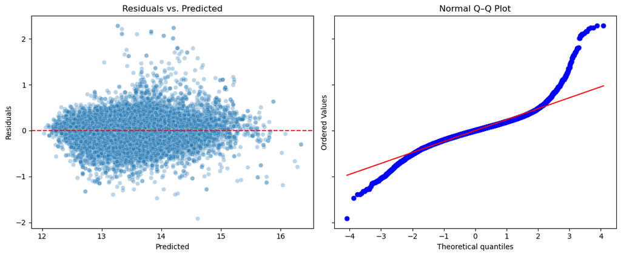

```python
residual_analysis_plots(ridge_model, X_te, y_test)
```

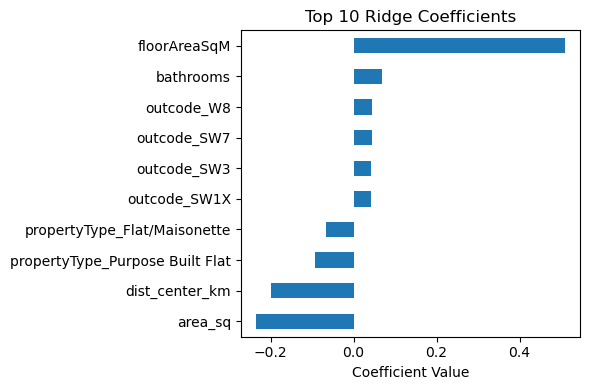

```python
import pandas as pd
import matplotlib.pyplot as plt

# ridge_model is your fitted RidgeCV
# X_train is the DataFrame you trained on

# 1. Turn the coefficients into a pandas Series
coef_series = pd.Series(ridge_model.coef_, index=X.columns)

# 2. Find the 10 biggest (by absolute value)
top10 = coef_series.abs().nlargest(10).index

# 3. Plot those 10 with their signs
coef_series.loc[top10].sort_values().plot.barh(figsize=(6,4))
plt.title('Top 10 Ridge Coefficients')
plt.xlabel('Coefficient Value')
plt.tight_layout()
plt.show()
```